# 20210308

Takala

本日は蔵王温泉スキー場に行ってきた．10年ぶりくらいだろうか．なつかしい．

天気がとても良く，3月＋平日＋コロナのせいかガラガラであった．

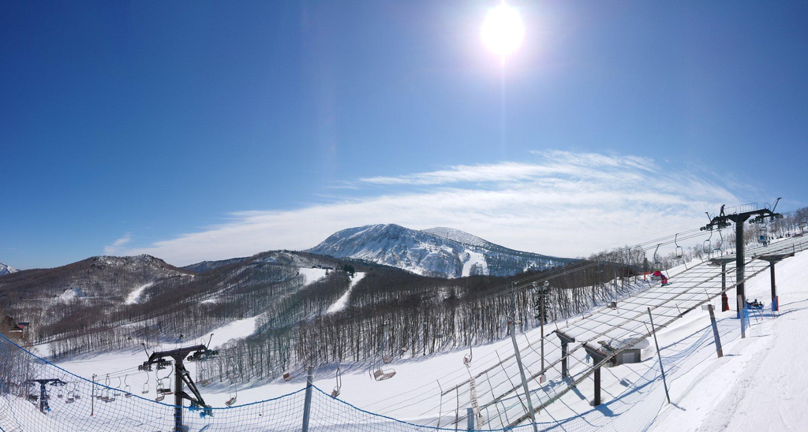

image

さて，蔵王温泉スキー場は日本有数の広さを誇るスキー場だ．

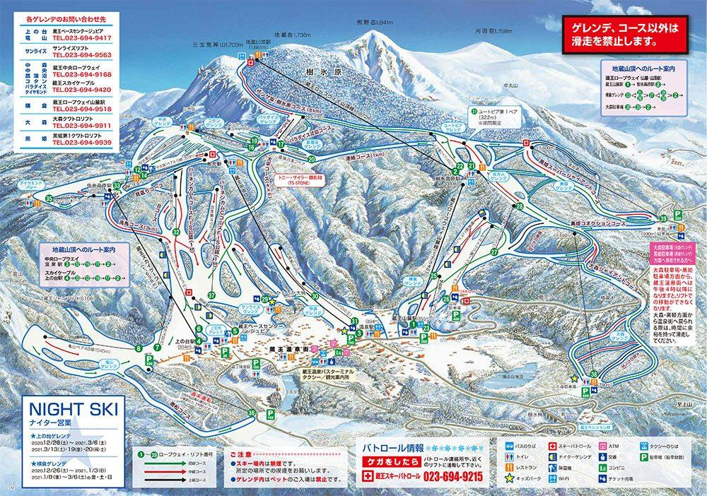

image

今日はリフトの一筆書き（同じコースは通ってよし）にチャレンジして，見事成功した．

最適解がどうかはわからないが実行可能解ではある．

ルートをメモしておく．（X）はリフト番号．

[0] 車を大森ゲレンデ駐車場においてスタート

[1] （38）に乗り大森ゲレンデの上部へ

[2] 黒姫コネクションを下り（39）に乗り黒姫上部へ

[3] 青い三角屋根に向かってユートピア下部に下り（２）に乗り地蔵山頂へ

[4] ザンゲ坂，ザイラコースを経由して菖蒲沼ゲレンデを下り（20）に乗り戻ってくる

[5] 大平コースを下り，上の台ゲレンデを横断し（6）に乗る

[6] 下って（4）に乗り中央高原へ

[7] ダイヤモンドバレーを下り（35）に乗る

[8] （33）に乗る

[9] 中央ゲレンデを滑り（12）へ乗る

[10] 同じく中央ゲレンデを滑り（14）へ乗る

[11] 上の台ゲレンデ方面に下り最下部の（5）に乗る

[12] 少し下り（37）に乗る

[13] サンライズゲレンデ方面に下り（29）に乗る

[14] かもしか大橋を渡り（31）に乗る

[15] （30）に乗る

[16] （3）に乗り鳥兜駅へ

[17] パラダイスゲレンデ方面へ下り（16）に乗る

[18] 再びパラダイスゲレンデ方面へ下り（19）に乗る

[19] （17）に乗り樹氷原コースをユートピア方面へ下り青い屋根のレストランで休憩

[20] 休憩後，百万人ゲレンデと横倉のカベを経由し，横倉ゲレンデを横断し（1）に乗る

[21] 少し歩いて上り百万人ゲレンデへ下り，横倉のカベを経由し，横倉ゲレンデを横断し（23）に乗る

[22] （25）に乗る

[23] 横倉ゲレンデを下り（26）に乗る

[24] （27）に乗る

[25] （28）に乗る

[26] （22）に乗る

これでユートピア，百万人，大森と下れば駐車場へ戻ってくる．

重複して乗ったリフトはなく，動いているやつには全部乗ったはず．

楽しかった～